# Estimating the impact of non-demographic effects on hospital activity growth in England | 2011-2019

Preliminary analysis to support the New Hospitals Programme

Author

Gabriel Hobro and Steven Wyatt

Published

October 2023

```r
library(tidyverse)
library(openxlsx)
library(readxl)
library(kableExtra)
library(plotly)
library(knitr)
library(janitor)
library(MASS)
library(mgcv)
```

This report has been authored by the following:

- Gabriel Hobro, NHP Demand and Capacity Modelling Analyst
- Steven Wyatt, Head of Research and Policy at the Strategy Unit

# Background

The government has committed to building more than 40 new hospitals by 2030. The New Hospital Programme (NHP), a partnership between DHSC and NHS England, aims to ensure that this new hospital infrastructure will meet the future needs of the population and that the required investment represents value for money.

Estimating future activity levels represents a critical early step in the process of scaling and designing new hospital infrastructure. The Strategy Unit (SU) has developed a model to support the NHP and its stakeholders to make robust and auditable assessments of activity that hospitals may need to accommodate in future.

The model accounts for a range of factors that might be expected to influence future levels of activity and resource (see figure 1 below).

This paper explore the impact of non-demographic growth (NDG) on hospital activity.

**Figure 1: Change factors accounted for in the modelling**

[figure not shown]

# Non-demographic growth

There are many factors that might impact on hospital activity growth that can be regarded as exogenous to a local health system and its population. These include the development and introduction of new medical technologies and clinical guidelines, national health policy, systemic (non-local) changes or secular trends in medical practice and patient expectations.

There are two approaches to estimating these effects: top-down, or residual methods, estimate non-demographic effects en masse by taking total historical growth and netting off the impact of other known factors. In contrast, bottom-up approaches start from the individual components of non-demographic growth, estimating each in turn before aggregation.

The top-down approach is expedient but has two key drawbacks. This approach relies on historical data and therefore assumes that historical non-demographic effects can reveal something important about the future effects. The limits of this approach were seen approximately 15 years ago when there was a radical change in funding growth for the NHS. The approach can also say little about the reasons that might lead to projected levels of non-demographic growth.

The bottom-up method provides this detailed underpinning and need not rely entirely on historical data to predict the future, but has other limitations. It requires more data, and more analytical effort to compute, and can only be applied to factors that are known. There is a risk then that hidden (unknown) sources of non-demographic growth are omitted leading to a systematic underestimation of the effect.

In this paper we provide some preliminary estimates of non-demographic growth using the top-down method. We net of the effects of changes in the population size and its age-sex profile, from total growth in hospital activity. It is important to note that we have not netted-off other important sources of activity growth (or reduction), such as changes in population morbidity (beyond those that can be proxied by age and sex), and the impact of efforts to reduce a health system’s dependence on hospital activity (i.e. activity mitigation).

# Methodology

## Data sources

Hospital activity data are sourced from Secondary User Services (SUS) via NCDR / UDAL. The tables used are:

- **vw_Data_SEM_AEA_EC_Combined** – A&E data. one row per A+E attendance.
- **tbl_Data_ SEM_APCS** – Inpatient spell. one row per continuous stay in a hospital setting.
- **tbl_Data_ SEM_OPA** – Outpatient appointments. One Row per Outpatient Appointment.

We use mid-year population estimates from the ONS to analyse population growth. These data are publicly available at: https://www.ons.gov.uk/peoplepopulationandcommunity/populationandmigration/populationestimates/datasets/populationestimatesforukenglandandwalesscotlandandnorthernireland

NB all ages over 90 are grouped together.

## Data wrangling

We combine the population data with hospital activity data to produce a table that includes counts of activity and population by single year of age, sex and calendar year, stratified by five activity types (inpatient elective spells, inpatient non-elective spells, inpatient maternity spells, A&E attendances at type 1 consultant-led emergency departments, and outpatient attendances).

Given lack of prior A&E data, all analyses are limited to 2011-2019.

(For maternity activity, we limit the sex to females and the age to 15-49.)

We then consider the difference between the growth in each of these variables, activity and population, to estimate the NDG values. This is illustrated in figure 2.

**Figure 2**

[figure not shown]

## Statistical methods

We start with some descriptive analysis, plotting trends in activity and in the population size, demonstrating changes in the population age-sex-structure and illustrating the relationship between age and activity rates by sex.

We adopt two approaches to estimate hospital activity growth by year, having controlled for changes in population size and the population age-sex structure: direct age-sex standardisation with log-linear regression and general-additive negative binomial regression.

The first method, whilst simpler, has the benefit of producing an age-sex adjusted rate for each year. The general additive models in the second method will make it less vulnerable to in-year variation in the relationship between age and activity.

We conclude by comparing the results from the two methods.

### Direct age-sex standardisation with log-linear regression

For each point of delivery, we calculate the ratios between activity and population for each combination of age and sex over each year in the data (2011-2019). We index the directly age-sex standardised rates to the rate observed in the baseline year.

We use a reference population, in this case the figures as of the baseline year, and then apply the rates from each year for each age-sex combination to the population of that age-sex combination in the baseline year.

This allows us to see how the activity would increase over time if the reference population (baseline year) was static.

Having calculated directly age-sex standardised hospital activity rates we estimate the average growth rates by fitting a simple linear regression model with the logged (age:sex standardised) rate as our dependant variable and year and the sole independent variable.

The exponentiated coefficient for this variable represents our non-demographic growth estimate using this first method.

### General-additive negative binomial regression

We use general additive negative binomial regression to estimate the impact of year on hospital activity.

Negative binomial regression is used since our outcome variable is a count and we have no reason to believe that the mean and standard deviation of these counts are similar. We include an offset term to allow for changes in population size and we fit thin-plate smooth terms for age separately for men and women, to allow for the non-linear relationship between age and hospital activity. We include a term for year.

The exponentiated coefficient for this variable, the incident risk ratio for year, represents our non-demographic growth estimate using this second method.

The form of the of the model is the following, where `yearN` is the number of years in relation to the baseline, and `ndg_data` is our data containing the population size (`population`) and activity count (`activity`) for each combination of `age` and `sex`.

```r
gam(activity ~ yearN + s(age, by = sex) + offset(log(population)),
               family = nb(link = 'log'),
               weights = population,
               data = ndg_data
```

NB for maternity , sex is not a variable given we restrict the data to females between the ages of 15 and 49.

# Results

```r
# loading the hospital activity data

hospitalActivity_Df <- readxl::read_excel(
  path = "data/Hospital activity data (SUS).xlsx"
  )

hospitalActivity_Df <- hospitalActivity_Df |>
  mutate(age = if_else(age>=90, 90, age))
```

```r
pod_lengthener_fn <- function(df) {
  df |> mutate(
    pod_long = case_when(pod == "IpElec" ~ "Elective admission",
                         pod == "IpEmer" ~ "Non-elective admission",
                         pod == "IpMat" ~ "Maternity admission",
                         pod == "opAtt" ~ "Outpatient attendance",
                         pod == "edAtt" ~ "A&E attendance",
                         TRUE ~ NA_character_
                         )
    )
}
```

```r
# Loading the population data

# Source: https://www.ons.gov.uk/peoplepopulationandcommunity/populationandmigration/populationestimates/datasets/populationestimatesforukenglandandwalesscotlandandnorthernireland

ons_population_series <- read.csv(
  file = "data/MYEB1_detailed_population_estimates_series_UK_(2020_geog21).csv")


# change the sex field to be more explicit
ons_population_series_1 <- ons_population_series |>
  mutate(sex = case_when(sex == "1" ~ "m",
                         sex == "2" ~ "f",
                         TRUE ~ NA_character_))

# lengthen the data (and remove the "population_" from the year)
ons_population_series_2 <- ons_population_series_1 |>
  pivot_longer(cols = population_2001:population_2020,
               names_to = "year",
               values_to = "population") |>
  mutate(year = as.numeric(str_extract(year, "\\d{4}")))

# get the national figures
ons_population_series_3 <- ons_population_series_2 |>
  group_by(country, sex, age, year) |>
  summarise(population = sum(population)) |>
  filter(country == "E")
```

```r
# Combining the activity and population data together

# We'll start by linking the data together
# gonna do this early on

hospital_activity_ndg_input <- hospitalActivity_Df |>
  filter(pod !="IpMat" | (sex !="m" & between(age, 15, 49))) |>
  group_by(year = yr,
           sex,
           age,
           pod) |>
  summarise(activity = sum(activity))


ons_population_ndg_input <- ons_population_series_3 |>
  dplyr::select(-country) |>
  group_by(year,
           sex,
           age) |>
  summarise(population = sum(population))


# This gives us a data frame containing activity and population for each
# combination of year, sex, age_group and point of delivery
# NB there will be repetition in the population field given it is not unique to pod
ndg_data <- left_join(hospital_activity_ndg_input, ons_population_ndg_input,
                      by = c("year", "sex", "age")) |>
  pivot_longer(cols = activity:population) |>
  filter(between(year, 2011,2019))
```

```r
# Age sex standardisation

# Get the ratios of activity to the general population per year
age_sex_standardisation_1 <- ndg_data |>
  pivot_wider() |>
  mutate(activity_rate = activity / population)

# Define the reference population, which is the baseline year
age_sex_standardisation_2 <- age_sex_standardisation_1 |>
  filter(year==2011)

# Join the data???
age_sex_standardisation_3 <- left_join(age_sex_standardisation_2,
                                       age_sex_standardisation_1,
                                       by = c("age", "sex", "pod"),
                                       suffix = c("_baseline", "_actual"))

# get the activity per year once age and sex have been adjusted for
# this is the population for that age-sex cohort in the baseline multiplied by the rate that year
age_sex_standardisation_4 <- age_sex_standardisation_3 |>
  mutate(activity_standardised = population_baseline * activity_rate_actual) |>
  dplyr::select(year = year_actual,
         sex,
         age,
         pod,
         population_standardised = population_baseline,
         activity_standardised,
         activity_rate = activity_rate_actual) |>
  mutate(check = activity_rate == activity_standardised / population_standardised)

age_sex_standardisation_5 <- age_sex_standardisation_4 |>
  group_by(year, pod) |>
  summarise(population_standardised = sum(population_standardised, na.rm = TRUE),
            activity_standardised = sum(activity_standardised, na.rm=TRUE))
```

```r
# Create the combined data for multiple linear regression

# hospital activity
hospital_activity_mlr_input <- hospitalActivity_Df |>
     filter(pod !="IpMat" | (sex !="m" & between(age, 15, 49))) |>
     group_by(year = yr,
              sex,
              age,
              pod) |>
     summarise(activity = sum(activity))

# create the combined data
ndg_mlr_data <- full_join(ons_population_series_3, hospital_activity_mlr_input,
                          by = c("sex", "age", "year")) |>
  filter(between(year, 2011, 2019)) |>
  ungroup()

# Get the activity rate and also set 2009 as year 0, 2010 as year 1, etc
ndg_mlr_data <- ndg_mlr_data |>
  mutate(actRate = activity / population,
         yearN = year - 2011) |>
  group_by( pod) |>
  mutate(population_share = population / mean(population)) |>
  ungroup()

# amend the sex to be a group variable
ndg_mlr_data$sex <- factor(ndg_mlr_data$sex)

ndg_mlr_data_split <- split(ndg_mlr_data, ndg_mlr_data$pod)
```

## Descriptive analysis

### Trends in activity and population size

The chart below shows the changes in the admissions and attendances by point of delivery as well as total population growth over the period from 2011 to 2019.

We can see that outpatient attendances and inpatient non-elective admissions outpace all other points of delivery as well as population growth.

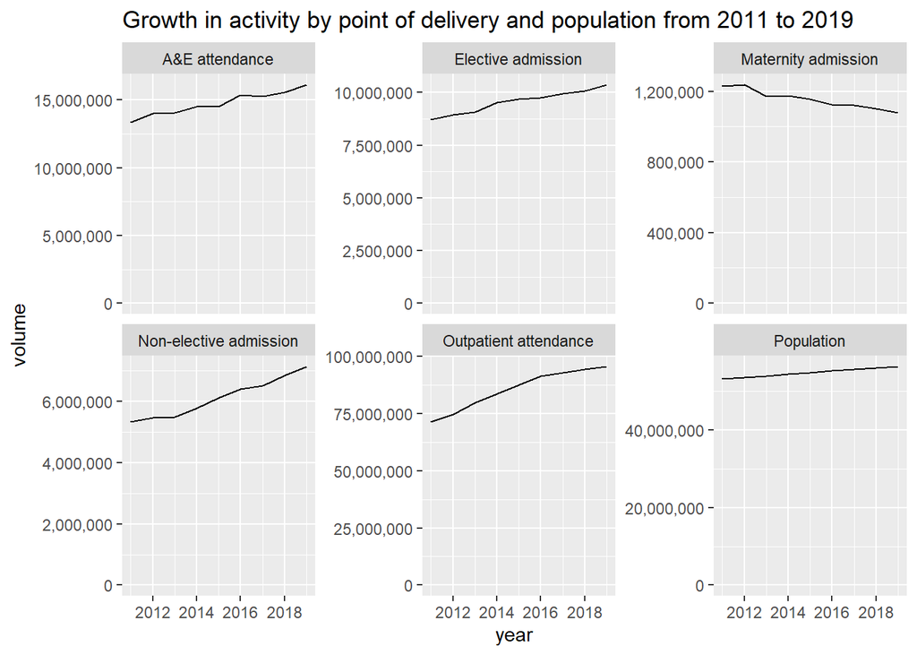

```r
# Creating time series plots

activity_volumes <- hospitalActivity_Df |>
  pod_lengthener_fn() |>
  group_by(year = yr,
           group = pod_long) |>
  summarise(volume = sum(activity)) |>
  filter(between(year, 2011, 2019))

population_volumes <- ons_population_series_3 |>
  group_by(year) |>
  summarise(volume = sum(population)) |>
  mutate(group = "Population") |>
  filter(between(year, 2011, 2019))

ggplot(
  bind_rows(activity_volumes, population_volumes),
  aes(x = year, y = volume)) +
  geom_line() +
  facet_wrap(~group, scales="free_y") +
  scale_y_continuous(labels = scales::comma_format(), limits = c(0,NA)) +
  scale_x_continuous(breaks= scales::pretty_breaks()) +
  ggtitle("Growth in activity by point of delivery and population from 2011 to 2019")
```

### Changes in age-sex profile

The chart below shows the age-sex structure of the population in 2011 and 2019.

We can see that the population aged over this time frame.

NB we have controlled for total population growth in this chart.

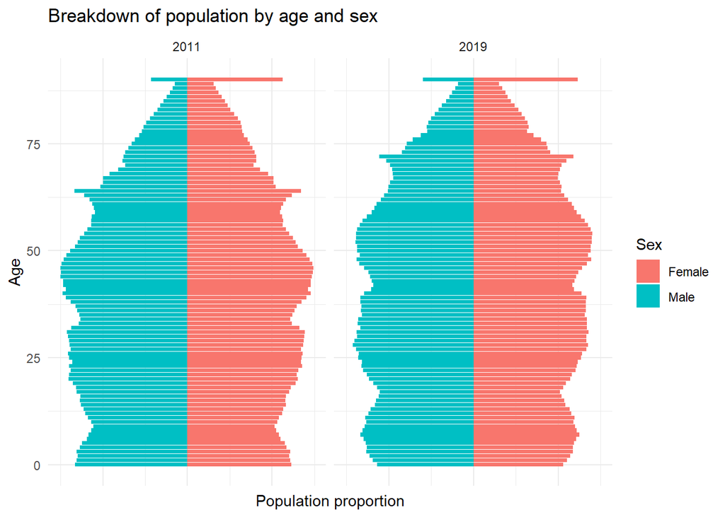

### Relationship between age and activity rates by sex

A complexity in this analysis is that age does not have a linear relationship with a person’s propensity to utilise hospital services.

This is demonstrated by the charts below, showing the hospital admission rate by age for each point of delivery in 2019.

With the exception of maternity, we can see that for each point of delivery, a person’s age is positively correlated to their propensity to utilise hospital services, peaking after the age of 75. This is true for both sexes. However, these increases are not linear, and in various cases, such as elective admissions around the age of 55, and A&E attendances in the adolescent period, there are local peaks. We can also see that females and males can have distinct trends, such as the peak in outpatient attendances for females in the early 30s which isn’t seen for males.

Maternity admissions are an exception in that the admission rate is largely symmetric, rapidly increasing from puberty, peaking in the early 30s, before immediately declining rapidly to near zero in the late 40s.

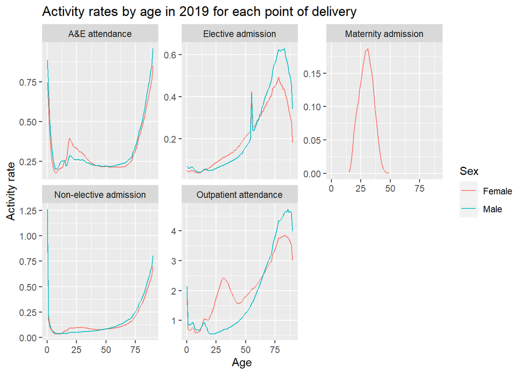

```r
ndg_mlr_data |>
  filter(year==2019, age<=90) |>
  pod_lengthener_fn() |>
  group_by(age, sex, pod_long) |>
  summarise(activity = sum(activity),
            population = sum(population)) |>
  mutate(actRate = activity / population) |>
  ggplot(aes(x=age,y=actRate,colour=sex)) +
  geom_line() +
  scale_y_continuous(labels = scales::comma_format()) +
  scale_color_discrete(name="Sex", labels = c("Female", "Male")) +
  ggtitle("Activity rates by age in 2019 for each point of delivery") +
  xlab("Age") +
  ylab("Activity rate") +
  facet_wrap(~pod_long,scales = "free_y")
```

## Statistical analysis

```r
# Calculating the log-linear regression on the age-sex standardised rates

age_sex_standardisation_regression <- age_sex_standardisation_5 |>
  mutate(log_activity_standardised = log(activity_standardised))

age_sex_standardisation_regression <- split(age_sex_standardisation_regression, age_sex_standardisation_regression$pod)

ip_elec_standardised_regression_model <- lm(log_activity_standardised ~ year, age_sex_standardisation_regression$IpElec)

ip_emer_standardised_regression_model <- lm(log_activity_standardised ~ year, age_sex_standardisation_regression$IpEmer)

ip_mat_standardised_regression_model <- lm(log_activity_standardised ~ year, age_sex_standardisation_regression$IpMat)

op_att_standardised_regression_model <- lm(log_activity_standardised ~ year, age_sex_standardisation_regression$opAtt)

ed_att_standardised_regression_model <- lm(log_activity_standardised ~ year, age_sex_standardisation_regression$edAtt)

# Deriving the confidence intervals
ci_ip_elec_standardised <- confint(ip_elec_standardised_regression_model,"year",level = 0.95)
ci_ip_emer_standardised <- confint(ip_emer_standardised_regression_model,"year",level = 0.95)
ci_ip_mat_standardised <- confint(ip_mat_standardised_regression_model,"year",level = 0.95)
ci_op_att_standardised <- confint(op_att_standardised_regression_model,"year",level = 0.95)
ci_ed_att_standardised <- confint(ed_att_standardised_regression_model,"year",level = 0.95)
```

```r
gam_2_ip_elec <- gam(activity ~ yearN + s(age, by = sex) + offset(log(population)),
           family = nb(link = "log"),
           weights = population_share,
           data = ndg_mlr_data_split$IpElec)
gam_2_ip_emer <- gam(activity ~ yearN + s(age, by = sex) + offset(log(population)),
           family = nb(link = "log"),
           weights = population_share,
           data = ndg_mlr_data_split$IpEmer)

gam_2_ip_mat <- gam(activity ~ yearN + s(age) + offset(log(population)),
           family = nb(link = "log"),
           weights = population_share,
           data = ndg_mlr_data_split$IpMat)

gam_2_op_att <- gam(activity ~ yearN + s(age, by = sex) + offset(log(population)),
           family = nb(link = "log"),
           weights = population_share,
           data = ndg_mlr_data_split$opAtt)

gam_2_ed_att <- gam(activity ~ yearN + s(age, by = sex) + offset(log(population)),
           family = nb(link = "log"),
           weights = population_share,            data = ndg_mlr_data_split$edAtt)
```

```r
library(broom)

#
ip_elec_gam_2_param <- tidy(gam_2_ip_elec, parametric = TRUE) #parametric is the traditional part, whereas non-paremetric is the smooths
ip_emer_gam_2_param <- tidy(gam_2_ip_emer, parametric = TRUE)
ip_mat_gam_2_param <- tidy(gam_2_ip_mat, parametric = TRUE)
op_att_gam_2_param <- tidy(gam_2_op_att, parametric = TRUE)
ed_att_gam_2_param <- tidy(gam_2_ed_att, parametric = TRUE)

# Add the std error multiplied by 1.96 (in a normal dist, mean and sd, the sd is the second order turning point on the curves)
ip_elec_gam_2_lwr <- exp(ip_elec_gam_2_param[[2,2]] - 1.96 * ip_elec_gam_2_param[[2,3]])-1
ip_elec_gam_2_hgr <- exp(ip_elec_gam_2_param[[2,2]] + 1.96 * ip_elec_gam_2_param[[2,3]])-1
ip_elec_gam_2_ci <- paste0("(",scales::percent(ip_elec_gam_2_lwr,accuracy=0.01),", ", scales::percent(ip_elec_gam_2_hgr, accuracy=0.01),")")

ip_emer_gam_2_lwr <- exp(ip_emer_gam_2_param[[2,2]] - 1.96 * ip_emer_gam_2_param[[2,3]])-1
ip_emer_gam_2_hgr <- exp(ip_emer_gam_2_param[[2,2]] + 1.96 * ip_emer_gam_2_param[[2,3]])-1
ip_emer_gam_2_ci <- paste0("(",scales::percent(ip_emer_gam_2_lwr,accuracy=0.01),", ", scales::percent(ip_emer_gam_2_hgr, accuracy=0.01),")")

ip_mat_gam_2_lwr <- exp(ip_mat_gam_2_param[[2,2]] - 1.96 * ip_mat_gam_2_param[[2,3]])-1
ip_mat_gam_2_hgr <- exp(ip_mat_gam_2_param[[2,2]] + 1.96 * ip_mat_gam_2_param[[2,3]])-1
ip_mat_gam_2_ci <- paste0("(",scales::percent(ip_mat_gam_2_lwr,accuracy=0.01),", ", scales::percent(ip_mat_gam_2_hgr, accuracy=0.01),")")

op_att_gam_2_lwr <- exp(op_att_gam_2_param[[2,2]] - 1.96 * op_att_gam_2_param[[2,3]])-1
op_att_gam_2_hgr <- exp(op_att_gam_2_param[[2,2]] + 1.96 * op_att_gam_2_param[[2,3]])-1
op_att_gam_2_ci <- paste0("(",scales::percent(op_att_gam_2_lwr,accuracy=0.01),", ", scales::percent(op_att_gam_2_hgr, accuracy=0.01),")")

ed_att_gam_2_lwr <- exp(ed_att_gam_2_param[[2,2]] - 1.96 * ed_att_gam_2_param[[2,3]])-1
ed_att_gam_2_hgr <- exp(ed_att_gam_2_param[[2,2]] + 1.96 * ed_att_gam_2_param[[2,3]])-1
ed_att_gam_2_ci <- paste0("(",scales::percent(ed_att_gam_2_lwr,accuracy=0.01),", ", scales::percent(ed_att_gam_2_hgr, accuracy=0.01),")")
```

### Age-sex standardised population growth

The charts below shows the change in activity relative to the baseline year once we conducted direct age-sex standardisation to control for changes in the age-sex profile of the population over time.

We can see that, with the exception of maternity, all pods showed an increase over time. However, outpatient attendances and inpatient non-elective attendances saw the biggest increase in activity relative to the baseline year.

There are also notable changes in trends for non-elective admissions in 2013 and for outpatient attendances in 2016.

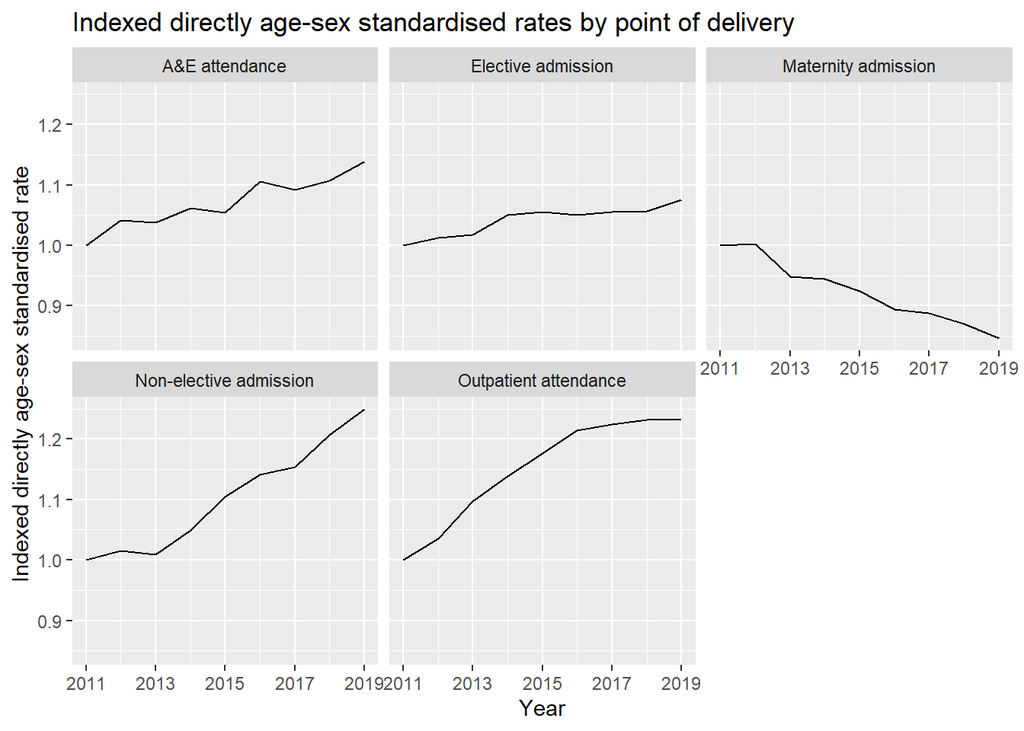

```r
age_sex_standardisation_5 |>
  pod_lengthener_fn() |>
  group_by(pod_long) |>
  arrange(pod_long,year) |>
  mutate(activity_standardised_relative = activity_standardised / first(activity_standardised)) |>
  ggplot() +
  geom_line(aes(x=year, y=activity_standardised_relative)) +
  ggtitle("Indexed directly age-sex standardised rates by point of delivery") +
  #scale_y_continuous(labels = scales::comma_format(), limits = c(0,NA)) +
  scale_x_continuous(breaks = seq(2011, 2019, by = 2)) +
  #theme_minimal() +
  xlab("Year") +
  ylab("Indexed directly age-sex standardised rate") +
  facet_wrap(~pod_long)
```

### Comparison of growth estimates for each method

We can see that growth rates are highest for outpatient attendances and non-elective admissions.

The two methods’ estimates are broadly similar for each point of delivery, although it is important to note that small differences when compounded can become significant.

The growth estimates are marginally lower for each point of delivery under the generalised additive model, where we more flexibly control for the effects of age and sex on activity.

Comparison of NDG values from standardisation with log-linear regression and a generalised additive model

| Point of delivery | Age-sex standardisation | Generalised additive model |
| --- | --- | --- |
| Inpatient elective | 0.83% (0.52%, 1.13% ) | 0.62% (0.48%, 0.76%) |
| Inpatient non-elective | 2.98% (2.5%, 3.5% ) | 2.17% (1.82%, 2.52%) |
| Inpatient maternity | -2.11% (-2.43%, -1.80% ) | -2.29% (-2.76%, -1.83%) |
| Outpatient attendance | 2.77% (1.9%, 3.6% ) | 2.49% (2.17%, 2.81%) |
| A&E attendance | 1.42% (1.02%, 1.82% ) | 1.31% (1.15%, 1.47%) |

# Discussion

Our analysis provides estimates the average annual growth of five activity types, having controlled for changes in the population size and age-sex profile, using two distinct methods, over the period from 2011 to 2019. The two methods (direct age-sex standardisation with log-linear regression and generalised additive negative binomial regression) generated similar results, although the growth rates estimated using the second method were consistently lower. We recommend decision-makers prioritise the use of the results from this second method, given that it handles the complex relationship between age and activity more flexibly and without the need of a standard population. This second method estimates average annual growth rates at 2.49% for outpatient attendances, 2.17% for inpatient non-elective admissions, 1.31% for A&E attendances, 0.62% for inpatient elective admissions, and -2.29% for inpatient maternity admissions.

## Limitations

The growth rates we estimated were averages over the study period, 2011-2019. Growth rates varied over this period, particularly for outpatient attendances and inpatient non-elective admissions. Different results would be obtained if different study-periods were used.

Activity within each of the 5 points of delivery we considered are heterogeneous, and therefore growth rates of subsets of activity within each point of delivery are likely to to vary, perhaps considerably. There is also some migration of activity between points of delivery over time as clinical practice changes. One of the explanations for lower growth rates of inpatient elective activity is the migration of planned procedures to outpatient care. Alternatively, more stable groupings of activity, might provide results that have greater utility for forward planning.

Whilst the methods we used net-off the effects of population growth and changes in the age-sex structure (including population ageing), other effects, that we may wish to net-off, remain. These include the impact of changes in age-specific morbidity rates and the effect of the health system’s efforts to increase hospital efficiency and efforts to move care out of hospital.

A more fundamental limitation of this analysis is its inability to provide insight into the causes of growth. This could be obtained by conducting analyses of the effects of specific drivers of growth in their own right.

Further work to improve out understanding of non-demographic growth effects would take three forms.

1. Regrouping activity into more stable categories.
2. Attempting to net-off other sources of growth and in particular changes in age-specific morbidity rates and the effect of hospital activity mitigation strategies.
3. Developing estimates of the growth that could be attributable to specific non-demographic effects such as the development and adoption of new medical technologies, changes in clinical guidelines and medical practice and changes in patient expectations.